# R, RStudio and R Markdown

Yuji Saikai ysaikai@unimelb.edu.au School of Mathematics and Statistics The University of Melbourne

These notes are based on:

- Chapter 3-5 of JMR — Jones, O., Maillardet, R., & Robinson, A. (2009). *Introduction to scientific coding and simulation using R*. CRC Press.
- Xie, Y., Allaire, J. J., & Grolemund, G. (2018). [*R markdown: The definitive guide*](https://bookdown.org/yihui/rmarkdown/). CRC Press.

# Introduction

For scientific computing, we do not really need sophisticated coding techniques. A real challenge is:

- problem identification,
- modelling, and
- design of solution algorithms.

Coding is, for us, merely implementation of algorithms.

That said, coding may take a lot of time, much more time than we often expect. Even when we have a clear idea, expressing it in a specific programming language often surprises us with an amount of time it takes. This is just like English writing. The best way to minimise the chance of this surprise is to do practice over and over again. The more, the better.

There seems to be two programming languages competing for the highest ROI (return on investment)—R and Python. Both are easy to learn, simple to use, and extremely popular. The popularity means a lot. Because so many people use them, we can find packages and code examples for pretty much any functionality we want to implement. This allows us to focus on problem solving, for which we code.

If you ever have created web pages using HTML or PDF documents using LaTeX, you know how steep learning curves are. Markdown is a modern lightweight language for creating equally rich documents with ease. R Markdown takes it to the next level. From a single source file, we can generate many different types of rich documents including HTML, PDF, MS Word, and presentation slides. More importantly, we can interweave computational results via R with document writing via Markdown.

# Coding in R

## Function

Just like a function in mathematics, a function in R takes arguments and returns a unique value. For example, for a mathematical function
$$f:x\mapsto \sin(x^2+1)$$
we may write

`f <- function(x) sin(x^2+1)`

as the the corresponding R function. To use multiple lines in a function definition, use a pair of braces `{ }` and `return` keyword as follows:

```r
f <- function(x) {
  xx <- x^2 # xx as a temporary variable
  xx <- xx + 1
  xx <- sin(xx)
  return(xx)
}
```

> Notice the use of `#` for comments.

An argument of the function need not be a scalar number; it may be a vector, list, or even more complex R object. Similarly, a returned value need not be a scalar number. For example, we will see in Numerical Integration that a function takes another function and returns a scalar number as definite integral.

## List

**List** is a convenient data structure when we want to pass and/or return multiple values of different types. For example, suppose
$$f(x_1,x_2) = x_1^2 - 2x_1x_2^2,$$
and we want to write a R function that returns not only its function value but also its derivatives:
$$\nabla f(x_1,x_2) =
\begin{pmatrix}
2x_1-2x_2^2\\
-4x_1x_2
\end{pmatrix}.$$

```r
f <- function(x) {
  # My naming convention:
  # re: return, f: function, and fg: function + gradient
  re <- list("f"=x[1]^2 - 2*x[1]*x[2]^2, "fg"=c(2*x[1]-2*x[2]^2, -4*x[1]*x[2]))
  return(re)
}
```

```r
f(c(3,1))
```

```
## $f
## [1] 3
##
## $fg
## [1]   4 -12
```

As you can see, if a return value is named, an output nicely categorises it. You can learn more about list in [this page](http://www.r-tutor.com/r-introduction/list).

## `for` loop

Suppose
$$f: (x,n) \mapsto \sum_{i=0}^n
x^i.$$
We may implement $f$ using `for` loop as follows:

```r
f1 <- function(x,n) {
  sum <- 0 # temporary variable
  for (i in 0:n) {
    sum <- sum + x^i
  }
  return(sum)
}
```

```r
x <- 4.1
n <- 5
```

Since $f$ computes the finite sum of a geometric sequence, it has the following explicit formula. For $x\neq1$,
$$f(x,n) = \frac{1-x^{n+1}}{1-x}.$$
Against this formula, we can verify `f1` for the following $(x,n)$:

| $x$ | $n$ | `f1(x,n)` | $\frac{1-x^{n+1}}{1-x}$ |
| --- | --- | --- | --- |
| 4.1 | 5 | 1531.96911 | 1531.96911 |

## `while` loop

We can also implement $f$ using `while` loop.

```r
f2 <- function(x,n) {
  sum <- 0
  i <- 0
  while (i <= n) {
    sum <- sum + x^i
    i <- i + 1
  }
  return(sum)
}
```

```r
f2(x,n)
```

```
## [1] 1531.969
```

Pretty much every iterative process can be implemented using `for` loops. But, sometimes, use of `while` loops makes code cleaner.

## Vector operation

Many iterative processes can be compactly implemented using vector operations. For example,

```r
sum(x^(0:n)) # n.b. sum here is a R built-in function
```

```
## [1] 1531.969
```

There are three key operations here:

1. `0:n` internally creates a vector `c(0,1,...,n)`.
2. Then, `x` is raised to the power of each element of the vector.
3. Finally, `sum` adds them up.

`x^(1:n)` part is called a vector operation because it takes a vector and processes the individual exponentiations in a batch. Vector operations are faster, and we should use them when performance is required (e.g., Size of the Mandelbrot set). But, if your code runs for a second or two, I recommend using loops in order to be explicit about what you are doing.

## `if` statement

### Are you prime?

The following code implements a function that returns `TRUE` or `FALSE` on whether a positive integer $n$ is prime. (Recall that $n$ is prime if it has only two factors: $1$ and $n$.)

```r
prime <- function(n) {
  if (n > 3) {
    for (m in 2:(n/2)) {
      if (n %% m == 0) {
        return(FALSE)
      }
    }
  }
  return(TRUE)
}
```

```r
prime(71) # Is 71 prime?
```

```
## [1] TRUE
```

Let’s see what algorithm is used here and how the code implements it.

- `if (n > 3)` because we know $2$ and $3$ are prime. So, if $n\leq3$, it jumps to the conclusion and returns `TRUE`.
- `if (n %% m == 0)` checks whether each candidate $m$ is a factor of $n$.
  - `%%` is the modulo operator, i.e. `n %% m` is for $n \bmod m$.
- `for (m in 2:(n/2))` restricts the candidate set to $\{2,3,\dots,\lfloor n/2 \rfloor\}$ because $m\in(n/2,n)$ cannot be a factor of $n$.
  - We can make the algorithm more efficient by replacing the upper bound $n/2$ with $\sqrt{n}$. Why? Because if $n=m_1m_2$, at least one of $m_1$ and $m_2$ must be less than or equal to $\sqrt{n}$.

### Roots of a quadratic

While we learn a lot about numerical approaches to solving $f(x)=0$ in Root Finding, there exists the analytical solution(s) if
$$f(x) = ax^2 + bx + c.$$
That is, the quadratic formula
$$x = \frac{-b \pm \sqrt{b^2-4ac}}{2a}.$$

The following `qf` function returns the roots of $f$ using the quadratic formula.

```r
qf <- function(a=1, b=0, c=-1) {
  discrim <- b^2 - 4*a*c # for the discriminant
  root1 <- (-b+sqrt(discrim))/(2*a)
  root2 <- (-b-sqrt(discrim))/(2*a)
  return(c(root1, root2))
}
```

It works with the default values $(a,b,c)=(1,0,-1)$

```r
qf()
```

```
## [1]  1 -1
```

and with any legitimate ones such as $(a,b,c)=(2,-5,3)$

```r
qf(2,-5,3)
```

```
## [1] 1.5 1.0
```

However, there are two illegal cases in the formula: $a=0$ and $b^2-4ac<0$. So, we should modify `qf` to handle the exceptions.

```r
qf <- function(a=1, b=0, c=-1) {
  discrim <- b^2 - 4*a*c

  # f is no longer quadratic but linear
  if (a == 0) {
    # f is a constant function
    if (b == 0) {
      if (c == 0) {
        return("Any x is a solution.")
      } else {
        return("No solutions.")
      }
    } else {
      return(-c/b)
    }
  }

  # Complex solutions
  if (discrim < 0) {
    return("No real solutions.")
  }

  # Non-degenerate cases
  root1 <- (-b+sqrt(discrim))/(2*a)
  root2 <- (-b-sqrt(discrim))/(2*a)
  return(c(root1, root2))
}
```

Now, it is more general. For example,

```r
qf(1,1,2)
```

```
## [1] "No real solutions."
```

## Recursive function

A recursive function is a function that calls itself. Although powerful and useful because many algorithms are recursive in nature, it often takes time to follow the flow of operations.

### Factorial

Let $f(n)$ denote the factorial of a non-negative integer $n$ (commonly denoted by $n!$). Specifically,
$$f(n) =
\begin{cases}
n\cdot(n-1)\cdots1 & \text{for } n \geq 1 \\
1 & \text{for } n = 0
\end{cases}$$

Notice the recursion for $n\geq1$,
$$f(n) = n\cdot(n-1)\cdots1 = n\cdot f(n-1)
.$$
That is, to return a value for an argument $n$, $f$ calls itself with another argument $n-1$. Let’s implement this simple recursive function.

```r
factorial <- function(n) {
  if (n >= 1) {
    return(n*factorial(n-1)) # calling itself
  } else {
    return(1)
  }
}
```

```r
factorial(10)
```

```
## [1] 3628800
```

Albeit illuminating, the use of recursion for the factorial with fixed $n$ seems contrived as we can simply use a `for` loop.

```r
re <- 1
for (m in 1:10) {
  re <- re*m
}
re
```

```
## [1] 3628800
```

The next example is more practical.

### Which of you are prime?

Suppose we want to find all primes up to $n$. A naive approach is to use a `for` loop to call `prime()` defined in Are you prime? $n-1$ times.

```r
primesieve1 <- function(n) {
  S <- c() # an empty solution set
  for (i in 2:n) {
    if (prime(i)) {
      S <- c(S, i)
    }
  }
  return(S)
}
```

However, there is a lot more efficient algorithm called the *Sieve of Eratosthenes*, which uses a recursive function.

0. Initialise $p = 2$, $P = \{\}$ and $C = \{2,3,\dots,n\}$.
1. Append $p$ to $P$ and remove all multiples of $p$ from $C$.
2. Set $p = \min(C)$ and $n = \max(C)$.
3. If $p > \sqrt{n}$ return $P+C$; otherwise, go back to #1.

```r
primesieve2 <- function(P,C) {
  p <- C[1] # for min(C) but faster
  n <- C[length(C)] # for max(C) but faster
  if (p > sqrt(n)) {
    return(c(P,C))
  } else {
    P <- c(P, p) # append p
    C <- C[C%%p != 0] # removing multiples of p
    return(primesieve2(P,C))
  }
}
```

Let’s see how faster the recursive algorithm performs for the same result.

```r
n = 10000
```

```r
tic()
re1 = primesieve1(n)
toc()
```

```
## 0.207 sec elapsed
```

```r
tic()
re2 = primesieve2(c(), 2:n)
toc()
```

```
## 0.004 sec elapsed
```

```r
if (identical(re1, re2)) {
  cat("Both found the same set containing", length(re1), "primes." )
}
```

```
## Both found the same set containing 1229 primes.
```

We will see another recursive function in Numerical Integration

## Plotting

Let’s draw a graph for the following hyperbolic tangent with some labels and annotations.
$$y = 2\tanh(x) =
2\frac{e^{x}-e^{-x}}{e^{x}+e^{-x}}$$

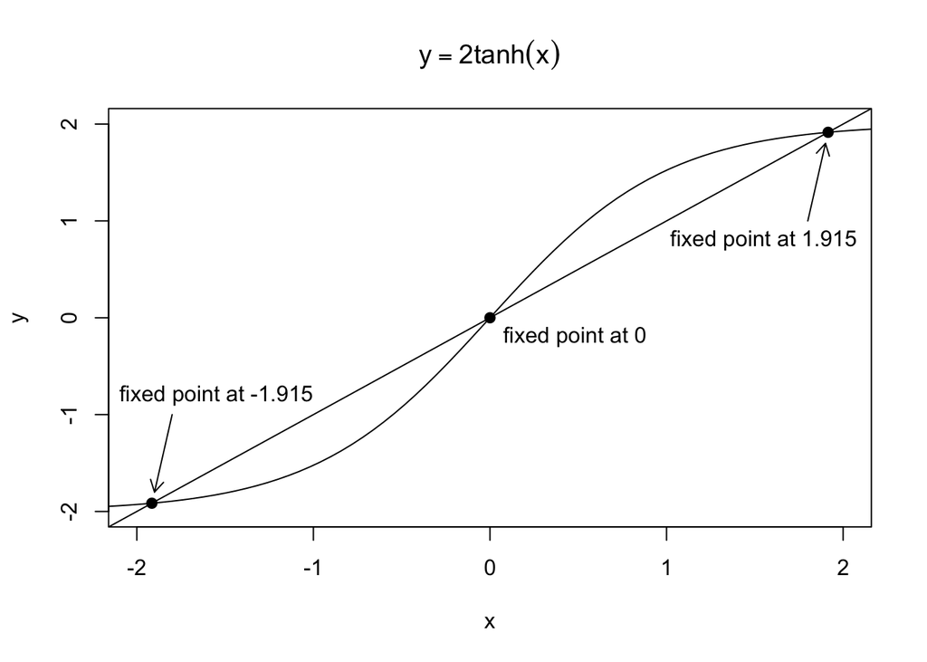

```r
x <- c(-1.915, 0, 1.915)
y <- c(-1.915, 0, 1.915)
plot(x, y, pch=19, xlim=c(-2,2), ylim=c(-2,2))
title(expression(y==2*tanh(x)))
curve(2*tanh(x), from=-3, to=3, add=TRUE)
curve(x*1, from=-3, to=3, add=TRUE)
text(-1.55, -.8, "fixed point at -1.915")
text(0, -.2, "fixed point at 0", pos=4)
text(1.55, .8, "fixed point at 1.915")
arrows(-1.8, -1, -1.9, -1.8, length=0.1)
arrows(1.8, 1, 1.9, 1.8, length=0.1)
```

Generating good figures can be painstaking because:

- there are so many parameters to tune, and
- the syntax is not quite logical or consistent, or sometimes even arbitrary.

Get ready for the pain…

# RStudio

Use of RStudio is not necessary, but it provides a very smooth environment for R coding. There are many tutorial materials on the web, and the following are short videos: one for RStudio in general and the other for R Markdown specifically.

[video not shown]

# R Markdown

## Markdown syntax

To me, the Markdown motto is “simplistic yet good enough”. Don’t forget to use line breaks generously to avoid unintended outputs. The following are some of Markdown syntax of heavy use.

### Headings

Just like Microsoft Word, [headings in Markdown](https://bookdown.org/yihui/rmarkdown/markdown-syntax.html#block-level-elements) not only produce section titles but also help to generate TOC (table of contents). For example, this section has a third-level header (`### Headings`), which appears in TOC.

### List

Start each item with `-` followed by a blank space . For example,

```
- Item 1
- Item 2
- ...
```

generates

- Item 1
- Item 2
- …

### Link

To attach a “location” to a “text”, write `[text](location)`. For example,

`[The University of Melbourne](https://www.unimelb.edu.au)`

generates

[The University of Melbourne](https://www.unimelb.edu.au)

`location` can be one for a local file in your computer. Moreover, an image is also inserted in a similar way. For example, `![](images/hello.png)` (i.e., additional `!` in front). We often leave empty inside the brackets `[ ]`.

### Indentation

Just use `>` and a blank space . For example,

```
> This is indented.
```

generates

> This is indented.

## YAML meta data

YAML (a recursive acronym for *YAML Ain’t Markup Language*) is used at the top of R Markdown documents for a [header](https://ourcodingclub.github.io/tutorials/rmarkdown/#identify) that specifies meta data for the document. This document’s YAML header looks as follows.

```
---
title: "R, RStudio and R Markdown"
author: |
  |
  | Yuji Saikai
  | ysaikai@unimelb.edu.au
  | School of Mathematics and Statistics
  | The University of Melbourne
output:
  html_document:
    theme: sandstone
    highlight: tango
    css: styles.css
    toc: true
    toc_float: true
---
```

## Code chunks

This is where R code is written. A code chunk may look as follows.

````markdown
```{r}
x <- 5 # 1st line in the chunk
y <- x^2 # 2nd line in the chunk
```
````

Conveniently, we can run R code inside R Markdown documents. Just put the cursor somewhere in the chunk and press `Cmd + Shift + Return` (`Ctrl + Shift + Enter` on Linux and Windows).

We can provide many parameters inside `{r}` to specify how the code output looks (e.g., plotting) and how the chunk itself is displayed in the generated document. For example, `{r, include=FALSE}` means that the code is run, but the chunk does not show up in the output document.

## Inline code

Besides code chunks, we can also insert values of R objects as an **inline text**. A consequence is that we need not and indeed should not separately copy and paste results of our analysis.

For example, suppose we have a result of computation equal to `97`. Then, a sentence “It predicts the score equal to 97.” should be written in R Markdown as:

```
It predicts the score equal to `r x`.
```

where the value `97` is stored in `x`.

If we update the analysis and the value of `x` (e.g., `x=97` to `x=88`), then the value in the output document will be automatically updated. This is a key feature of R Markdown for **reproducibility**, an idea much advocated in scientific communities. (See [replication crisis](https://www.vox.com/future-perfect/21504366/science-replication-crisis-peer-review-statistics).)

We use this feature in for loop above. To render the table, the source has

```
| $x$ | $n$ | `f1(x,n)` | $\frac{1-x^{n+1}}{1-x}$ |
| ---: | ---: | ---: | ---: |
| `r x`| `r n` | `r f1(x,n)` | `r (1-x^(n+1))/(1-x)` |
```

Much more detais are found [here](https://bookdown.org/yihui/rmarkdown/r-code.html).